# Pentathlon II

## Setup

Review the assignment questions on Canvas (week3/pentathlon-II.pdf). Create an Rmarkdown document (pentathlon-II.Rmd) in which you calculate the CLV for each of the plans an 8 week periods. The relevant data is in `data/pentathlon-II.xlsx` Also, use the average subscription churn and revenue numbers provided in `data/pentathlon-II-avg.csv` to simulate the effect of the different email frequencies over a 104 week period and generate a line plot to compare the five CLV curves. Are your results consistent with your answer to question 3 in week3/pentathlon-II.pdf file on Canvas? Why (or why not)?

## Hints

Please generate an HTML (Notebook) with your answers to all the questions listed in the week3/pentathlon-II.pdf file on Canvas. When you have finished editing the the jupyter notebook and generated the HTML report make sure to save, commit, and push to GitLab. We will collect all files from GitLab after the due date.

## Analysis

Load both `data/pentathlon-II.xls` and `data/pentathlon-II-avg.csv` for use in your analysis. Note that you still have to calculate the weekly discount rate based on the annual discount rate mentioned below. http://www.sthda.com/english/wiki/r-xlsx-package-a-quick-start-guide-to-manipulate-excel-files-in-r

```r
install.packages("xlsx", dependencies = TRUE)
library("xlsx")
```

[output not shown]

```r
pentathlon8 <- read.xlsx('data/pentathlon-II.xlsx',1, header=FALSE)
```

[output not shown]

```r
pentathlon104 <- read.csv(file="data/pentathlon-II-avg.csv", header=TRUE, sep=",")
```

The variables in `data/pentathlon-II-avg.csv` are:

- `schurn` is the average subscription churn over the 8 weeks of the test
- `rev_sub` is the average revenue from subscribers
- `rev_unsub` is the average revenue from non-subscribers

A few assumptions to start with:

## attrition rate takes place at next week

## revenue concludes the whole week, pay by the end of week. So from week1, we apply discount rate.

```r
## assumption and global variables
## use half a week discount rate
discount <- .1 ## annual discount rate
discount_period <- 0.5:7.5
cogs <- .6
week_discount <- (1+discount)^(1/52) - 1
```

Create a code chunk that contains a function that you can call to calculate the CLV for each of the 5 email plans.

```r
## return value of CLV for each week
## for every experiment(different emails received), variables are churn rate, average revenue of subscribers and unsubscribers
clv <- function(churn, revenue_s, revenue_ns, week) {
  retention_s <- c(1, cumprod(1 - churn[1:(week-1)]))
  ###churn rate's definition is different from homealarms case
  #retention_ns <- cumsum(c(0, churn*retention_s)[1:week])
  retention_ns <- 1 - retention_s
  revenue_s_t <- revenue_s * retention_s
  revenue_ns_t <- revenue_ns * retention_ns
  revenue_t <- revenue_s_t + revenue_ns_t
  cos_t <- revenue_t * cogs
  revenues <- revenue_t - cos_t
  PV_r <- revenues / (1 + week_discount)^discount_period
  CLV <- cumsum(PV_r)
  df <- data.frame(churn, revenue_s, revenue_ns, retention_s, retention_ns, discount_period, revenue_s_t, revenue_ns_t, revenue_t, cos_t, revenues, PV_r, CLV)
  return(CLV)
  #return(PV_r)
  #return(df)
}
```

Question 1

```r
week = 8
List = list(1:week)
CLV = rep(List,5)
# use List to contain every experiment's CLV for 8 weeks

for (i in 1:5){ ##Q how to subtract row by row names
  a = pentathlon8[2+(i-1)*5,c(2:(week+1))]
  churn = as.numeric(as.character(t(a[1,])))
  b = pentathlon8[3+(i-1)*5,c(2:(week+1))]
  revenue_s = as.numeric(as.character(t(b[1,])))
  c = pentathlon8[4+(i-1)*5,c(2:(week+1))]
  revenue_ns = as.numeric(as.character(t(b[1,])))

  CLV[i] <- list(clv(churn, revenue_s, revenue_ns, week))
  #print(CLV[i])
  #print(PV_r)
}
```

[output not shown]

Next, create a tibble with 6 columns. Five columns for the CLV series for each of the plans and one column for the `weeks` variable defined above. Call the `clv` function you created above to fill-in the columns.

```r
## create the tibble (data.frame)
df.8 <- tibble::tibble(discount_period,CLV[[1]],CLV[[2]],CLV[[3]],CLV[[4]],CLV[[5]])
colnames(df.8) <- c("week", "email_1", "email_2", "email_3", "email_4", "email_5")
df.8
```

```
# A tibble: 8 x 6
   week email_1 email_2 email_3 email_4 email_5
  <dbl>   <int>   <int>   <int>   <int>   <int>
1   0.5       1       1       1       1       1
2   1.5       2       2       2       2       2
3   2.5       3       3       3       3       3
4   3.5       4       4       4       4       4
5   4.5       5       5       5       5       5
6   5.5       6       6       6       6       6
7   6.5       7       7       7       7       7
8   7.5       8       8       8       8       8
```

Question 2

```r
NumberOfHighest_CLV = c()
names(df.8) <- c(" ", "  ", " "," "," ","")
for (i in 1:8){
  NumberOfHighest_CLV <- c(NumberOfHighest_CLV, which.max(df.8[i,2:6]))
}
week = 1:8
tibble::tibble(week,NumberOfHighest_CLV)
```

```
# A tibble: 8 x 2
   week NumberOfHighest_CLV
  <int>               <int>
1     1                   1
2     2                   1
3     3                   1
4     4                   1
5     5                   1
6     6                   1
7     7                   1
8     8                   1
```

```r
count = table(NumberOfHighest_CLV)
count
```

```
NumberOfHighest_CLV
1
8
```

Next, generate three line plots that compare the CLV curves for each of the five plans. The first graphs should plot weeks 1 through 8. The second graph should plot weeks 1 through 52 and the final graph should show weeks 1 through 104.

Question 4

```r
#chose one from period
clv104 <- function(churn, revenue_s, revenue_ns, week) {
  Churn <- rep(churn,week-1)
  Revenue_s <- rep(revenue_s,week)
  Revenue_ns <- rep(revenue_ns,week)
  retention_s <- c(1, cumprod(1-Churn))
  retention_ns <- cumsum(c(0, churn*retention_s)[1:week])
  revenue_s_t <- Revenue_s * retention_s
  revenue_ns_t <- Revenue_ns * retention_ns
  revenue_t <- revenue_s_t + revenue_ns_t
  cos_t <- revenue_t * cogs
  revenues <- revenue_t - cos_t
  discount_period <- 0.5:(week-0.5)
  PV_r <- revenues / (1 + week_discount)^discount_period
  CLV <- list(cumsum(PV_r))
  #df <- data.frame(churn, revenue_s, revenue_ns, retention_s, retention_ns, discount_period, revenue_s_t, revenue_ns_t, revenue_t, cos_t, revenues, PV_r, CLV)
  return(CLV)
  #return(PV_r)
}
```

```r
List_CLV = list()
week = 104
for (i in 1:5){
  churn = pentathlon104$schurn[i]
  revenue_s = pentathlon104$rev_sub[i]
  revenue_ns = pentathlon104$rev_unsub[i]
  List_CLV[i] = clv104(churn, revenue_s, revenue_ns, week)
}
```

```r
df.104 = as.data.frame(do.call(cbind, List_CLV))
# Change colnames of all columns
colnames(df.104) <- c("email_1", "email_2", "email_3", "email_4", "email_5")
```

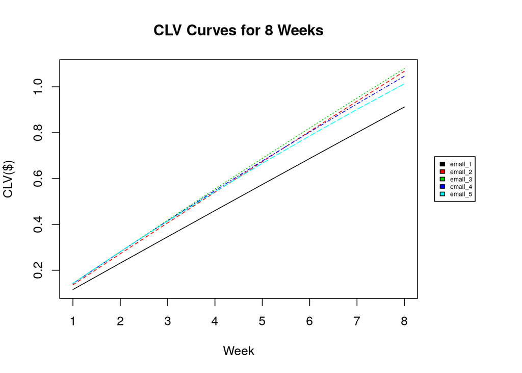

```r
## generate graph 1
week = 8
df.104.8 = df.104[1:week,]
nn <- ncol(df.104.8)
layout(matrix(c(1,2),nrow=1), width=c(4,1))
par(mar=c(5,4,4,0)) #No margin on the right side
matplot(df.104.8,type="l",ylab='CLV($)',xlab='Week',main = 'CLV Curves for 8 Weeks',xaxt="n", xlim=c(1, week))
axis(1, at = 0:week)
#axis(side=1,at = Weeks,labels=Weeks)
par(mar=c(5,0,4,2)) #No margin on the left side
plot(c(0,1),type="n", axes=F, xlab="", ylab="")
legend("center", colnames(df.104.8),col=seq_len(nn),cex=0.5,fill=seq_len(nn))
```

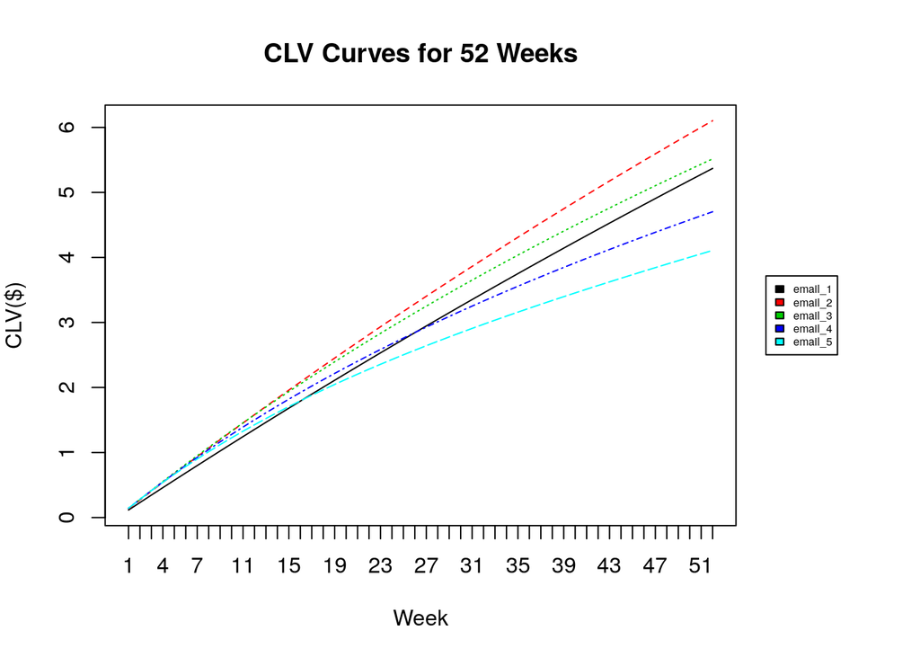

```r
# https://www.dummies.com/programming/r/how-to-add-titles-and-axis-labels-to-a-plot-in-r/
## generate graph 2
week = 52
df.104.52 = df.104[1:week,]
nn <- ncol(df.104.52)
layout(matrix(c(1,2),nrow=1), width=c(4,1))
par(mar=c(5,4,4,0)) #No margin on the right side
matplot(df.104.52,type="l",ylab='CLV($)',xlab='Week',main = 'CLV Curves for 52 Weeks',xaxt="n", xlim=c(1, week))
axis(1, at = 1:week)
#axis(side=1,at = Weeks,labels=Weeks)
par(mar=c(5,0,4,2)) #No margin on the left side
plot(c(0,1),type="n", axes=F, xlab="", ylab="")
legend("center", colnames(df.104.52),col=seq_len(nn),cex=0.5,fill=seq_len(nn))
```

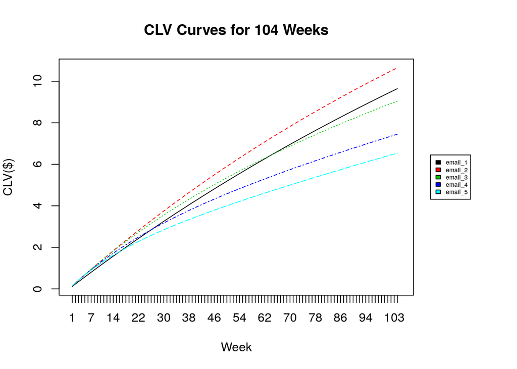

```r
## generate graph 3
week = 104
df.104.104 = df.104[1:week,]
nn <- ncol(df.104.104)
layout(matrix(c(1,2),nrow=1), width=c(4,1))
par(mar=c(5,4,4,0)) #No margin on the right side
matplot(df.104.104,type="l",ylab='CLV($)',xlab='Week',main = 'CLV Curves for 104 Weeks',xaxt="n", xlim=c(1, (week+1)))
axis(1, at = 1:week)
#axis(side=1,at = Weeks,labels=Weeks)
par(mar=c(5,0,4,2)) #No margin on the left side
plot(c(0,1),type="n", axes=F, xlab="", ylab="")
legend("center", colnames(df.104.104),col=seq_len(nn),cex=0.5,fill=seq_len(nn))
```

#Answer Q4 The result is different from question 3. For 8 weeks, 3-email frequency has the highest CLV. For 52 weeks(1 year) and 104 weeks(2 years), 2-email frequency has the highest CLV. The reason can be caused by different cacluation method used with average churn rate and revenues of 8 weeks’ experiment. When flunctuating different churn rate times revenues for two categories according and sum up the two revenues, the result is different using the whole average.

#Answer Q5 One problem is the promotion of products is sent from one department, which decreases the experiment’s credibility in determining the effects of promotion given in real life, it is unlikely to receive one type of promotion. The adjustment could be have a combination of two to three departments sending out promotion in a regular pattern. Second problem could be some bias in lack of no controlled trail of 0-email frequency. The research is conducted based on the assumption that email is good source of advertisement. I strongly recommend use a compared experiment of no-email trail to certify that email promotes sale. A third problem could be the source of volunteers participating in the experiment. There is no evidence showing they are equally neutral to the brand. Although it is said the volunteers are randomly distributed to each group, I recommend pick up people who never heard of the brand.

Please generate a *reproducible* Notebook or HTML report with all your results and your answers to the questions listed in the pentathlon-II.pdf file on Canvas.

When you have finished editing this Rmarkdown document make sure to save, commit, and push it to GitLab. We will collect all the Rmarkdown files from GitLab after the due date.

Note: Make sure to check on GitLab if the CI pipeline completed successfully. If it did, you should see a green check mark on the right-hand side of the main repo project page